# lab3

Christine Lucille Kuryla

2024-12-12

# Introduction

Does having a college degree increase life excitement and satisfaction? Naively, there seems to be a relationship. Our question in this lab is whether having a bachelor degree is related to life satisfaction over time in the way they are related at the individual level. In other words, as more of our population is getting bachelor’s and college degrees, are their lifes getting more exciting (higher life satisfaction)?

The variables we will be using come from the GSS dataset.

### Variable: life

“In general, do you find life exciting, pretty routine, or dull?”

1 Exciting  
2 Routine 3 Dull

We will recode to the more intuitive 3 Exciting  
2 Routine 1 Dull

We will also dichotomize it so that exciting_life = 1 if people respond “exciting” and exciting_life = 0 otherwise.

### Variable: degree / baplus

0 Less than high school  
1 High school 2 Associate/junior college  
3 Bachelor’s  
4 Graduate

We will dichotomize it so that baplus = 1 if people have a bachelors or graduate degree and baplus = 0 otherwise.

## Naive Relationship

```r
gss_for_ts <- read_csv("data/gss_raw_subset_for_ts.csv") %>%
       mutate(happiness = ifelse(happy == 1, 1, 0),
              excellent_health = ifelse(health == 1, 1, 0),
              good_health = ifelse(health == 2, 1, 0),
              fair_health = ifelse(health == 3, 1, 0),
              poor_health = ifelse(health == 4, 1, 0),
              exciting_life = ifelse(life == 1, 1, 0),
              nonextreme_views = ifelse(polviews %in% c(3, 4, 5), 1, 0),
              extreme_views = ifelse(polviews %in% c(1, 2, 6, 7), 1, 0),
              moderate_views = ifelse(polviews == 4, 1, 0),
              cohort = floor(year - age),
              over50 = ifelse(age >= 50, 1, 0),
              boomer = ifelse(cohort >= 1946 & cohort <= 1964, 1, 0) ,
              millenial = ifelse(cohort >= 1981 & cohort <= 1996, 1, 0) ,
              bornin40s = ifelse(cohort >= 1940 & cohort <= 1949, 1, 0),
              sat_w_finances = ifelse(satfin == 1, 1, 0),
              income = realinc) %>%
    mutate(life = 4 - life) %>% # more intuitive
    mutate(baplus = ifelse(degree >= 3, 1, 0)) %>% # Dichotomise bachelors/graduate vs no bachelors/graduate
    mutate(happy = 4 - happy) %>%
    mutate(health = 5 - health)
# gss_for_ts <- read_csv("data/gss_raw_subset_for_ts.csv") %>%
#   mutate(life = 4 - life) %>% # more intuitive
#   mutate(baplus = ifelse(degree >= 3, 1, 0)) %>% # Dichotomise bachelors/graduate vs no bachelors/graduate
#   mutate(exciting_life = ifelse(life == 1, 1, 0)) %>%
#   mutate(happy = 4 - happy) %>%
#   mutate(health = 5 - health)

colnames(gss_for_ts)
```

```
##  [1] "year"             "trust"            "sex"              "age"
##  [5] "partyid"          "wrkstat"          "happy"            "degree"
##  [9] "realinc"          "health"           "life"             "satfin"
## [13] "polviews"         "educ"             "happiness"        "excellent_health"
## [17] "good_health"      "fair_health"      "poor_health"      "exciting_life"
## [21] "nonextreme_views" "extreme_views"    "moderate_views"   "cohort"
## [25] "over50"           "boomer"           "millenial"        "bornin40s"
## [29] "sat_w_finances"   "income"           "baplus"
```

```r
# Correlation between the variables?
gss_for_ts %>%
  dplyr::select(degree, life) %>%
  na.omit() %>%
  cor()
```

```
##           degree      life
## degree 1.0000000 0.1976825
## life   0.1976825 1.0000000
```

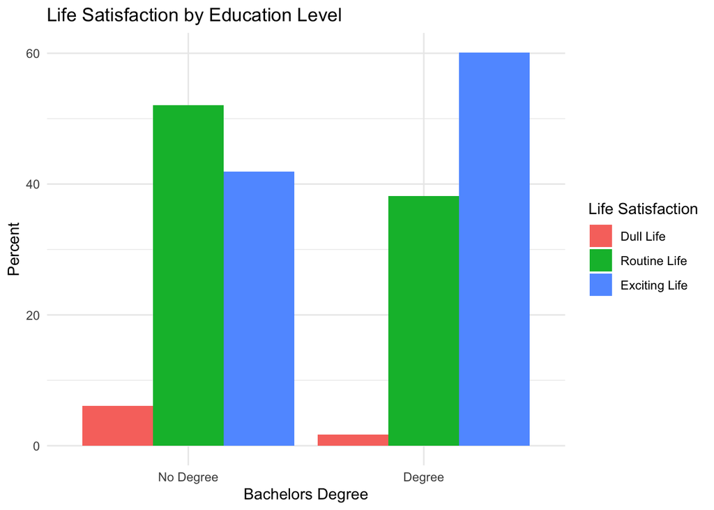

```r
# Yes, and it is positive.

# Dichotomize bachelors vs no bachelors and visualize it
gss_for_ts %>%
  select(baplus, life, year) %>%
  na.omit() %>%
  mutate(life = factor(life,
                      levels = 1:3,
                      labels = c("Dull Life", "Routine Life", "Exciting Life"))) %>%
  mutate(baplus = factor(baplus,
                   levels = c(0, 1),
                   labels = c("No Degree", "Degree"))) %>%
  dplyr::count(life, baplus) %>%
  group_by(baplus) %>%
  mutate(percent = n / sum(n) * 100) %>%
     ggplot(aes(x = factor(baplus), y = percent, fill = factor(life))) +
     geom_bar(stat = "identity", position = "dodge") +
     labs(
         title = "Life Satisfaction by Education Level",
         x = "Bachelors Degree",
         y = "Percent",
         fill = "Life Satisfaction"
     ) +
     theme_minimal()
```

# Time Series Analysis

## Q1: Create time series and interpolate

1. Create a multivariate time series; perform any interpolations.

```r
# get means by year
by.year <- aggregate(subset(gss_for_ts, sel = -year), list(year = gss_for_ts$year), mean, na.rm = T)

# interpolate for some missing years

# First, add the extra years
unique(gss_for_ts$year) # years in dataset
```

```
##  [1] 1972 1973 1974 1975 1976 1977 1978 1980 1982 1983 1984 1985 1986 1987 1988
## [16] 1989 1990 1991 1993 1994 1996 1998 2000 2002 2004 2006 2008 2010 2012 2014
## [31] 2016 2018 2021 2022
```

```r
extra_years <- setdiff(seq(1972, 2018), unique(gss_for_ts$year)) # years missing for a continus TS; skip 2020+ because of covid
dim(by.year)[1] # number of years in original data (34)
```

```
## [1] 34
```

```r
length(extra_years) # number of years to add (15)
```

```
## [1] 15
```

```r
dim(by.year)[1] + length(extra_years) # sum (49)
```

```
## [1] 49
```

```r
by.year[35:49, "year"] <- as.vector(extra_years) # add the extra years
by.year <- dplyr::arrange(by.year, year) # arrange by year

# Now make a time series object by.year.ts and interpolate using na.approx
by.year.ts <- ts(by.year)
by.year.ts <- na.approx(by.year.ts)

# calculate pct
by.year.ts <- as.data.frame(by.year.ts)
by.year.ts <- mutate(by.year.ts,
                     happy_pct = happiness*100,
                     excellent_health_pct = excellent_health*100,
                     exciting_life_pct = exciting_life*100,
                     boomer_pct = boomer*100,
                     bornin40s_pct = bornin40s*100,
                     over50_pct = over50*100,
                     sat_w_finances_pct = sat_w_finances*100,
                #     millenial_pct = millenial*100,
                     ba_pct = baplus*100)

# get rid of 1972,1973, after 2018 and convert back to time series object
 by.year.ts <- ts(subset(by.year.ts, year >= 1974 & year <= 2018))

head(by.year.ts)
```

```
## Time Series:
## Start = 1
## End = 6
## Frequency = 1
##   year    trust      sex      age  partyid  wrkstat    happy    degree  realinc
## 1 1974 1.608610 1.534367 44.59134 2.598220 3.585580 2.247973 0.9986514 32124.53
## 2 1975 1.648173 1.550336 44.30774 2.501010 3.575168 2.197980 0.9523170 29403.92
## 3 1976 1.593311 1.553702 45.28667 2.430769 3.625083 2.215477 0.9886135 28273.75
## 4 1977 1.623226 1.547059 44.66316 2.405797 3.228105 2.229208 0.9986877 32640.56
## 5 1978 1.653141 1.580287 44.00984 2.590701 3.355744 2.247858 1.0392413 30178.04
## 6 1979 1.617810 1.571819 44.49224 2.601494 3.346469 2.226870 1.0636780 30755.62
##     health     life   satfin polviews     educ happiness excellent_health
## 1 2.993243 2.387656 1.920162 3.979433 11.80081 0.3790541        0.3283784
## 2 2.980524 2.399252 1.956728 3.960630 11.68258 0.3286195        0.3237072
## 3 2.976636 2.410847 1.926273 4.020700 11.70127 0.3408939        0.3130841
```

[output cut: 38 more lines]

```r
colnames(by.year.ts)
```

```
##  [1] "year"                 "trust"                "sex"
##  [4] "age"                  "partyid"              "wrkstat"
##  [7] "happy"                "degree"               "realinc"
## [10] "health"               "life"                 "satfin"
## [13] "polviews"             "educ"                 "happiness"
## [16] "excellent_health"     "good_health"          "fair_health"
## [19] "poor_health"          "exciting_life"        "nonextreme_views"
## [22] "extreme_views"        "moderate_views"       "cohort"
## [25] "over50"               "boomer"               "millenial"
## [28] "bornin40s"            "sat_w_finances"       "income"
## [31] "baplus"               "happy_pct"            "excellent_health_pct"
## [34] "exciting_life_pct"    "boomer_pct"           "bornin40s_pct"
## [37] "over50_pct"           "sat_w_finances_pct"   "ba_pct"
```

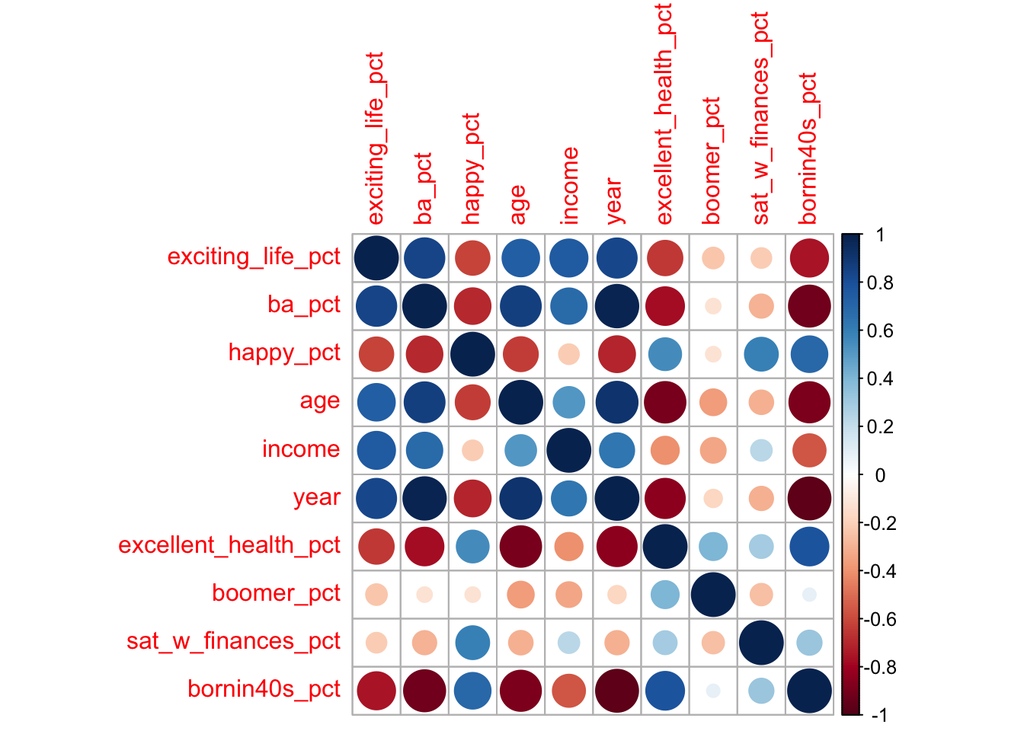

```r
# correlations
cor.vars <- c("exciting_life_pct", "ba_pct", "happy_pct", "age", "income", "year", "excellent_health_pct", "boomer_pct", "sat_w_finances_pct", "bornin40s_pct")
# cor.vars <- colnames(by.year.ts)
cor.dat <- by.year.ts[, cor.vars]



corrplot::corrplot(cor(cor.dat))
```

Exiting life and percent with a higher degree are positively correlated with year, which suggests that both increase as time passes. The percent of the population with a bachelors or higher is positively correlated with people reporting a more exciting life, which suggestions that as the proportion of the population with a bachelors or higher increases, life satisfaction/ excitement also tends to increase.

## Q2: Graph relationships

2. Graph the relationships between X and Y. Explain how you think Y should relate to your key Xs.

```r
library(reshape2)


meltMyTS <- function(mv.ts.object, time.var, keep.vars){
  # mv.ts.object = a multivariate ts object
  # keep.vars = character vector with names of variables to keep
  # time.var = character string naming the time variable
  require(reshape2)

  if(missing(keep.vars)) {
    melt.dat <- data.frame(mv.ts.object)
  }
  else {
    if (!(time.var %in% keep.vars)){
      keep.vars <- c(keep.vars, time.var)
    }
    melt.dat <- data.frame(mv.ts.object)[, keep.vars]
  }
  melt.dat <- melt(melt.dat, id.vars = time.var)
  colnames(melt.dat)[which(colnames(melt.dat) == time.var)] <- "time"
  return(melt.dat)
}

# Make a character vector naming the variables we might want to plot
keep.vars <- c("year", "happy_pct", "age", "ba_pct", "income", "excellent_health_pct", "exciting_life_pct")
keep.vars <- setdiff(colnames(by.year.ts), "year")

# Use meltMyTS to transform the data to a 3-column dataset containing a column
# for time, a column for variable names, and a column of values corresponding to
# the variable names


plot.dat <- meltMyTS(mv.ts.object = by.year.ts, time.var = "year", keep.vars = keep.vars)
head(plot.dat)
```

```
##   time variable    value
## 1 1974    trust 1.608610
## 2 1975    trust 1.648173
## 3 1976    trust 1.593311
## 4 1977    trust 1.623226
## 5 1978    trust 1.653141
## 6 1979    trust 1.617810
```

```r
# Use ggMyTS to plot any of the variables or multiple variables together


ggMyTS <- function(df, varlist, line = TRUE, point = TRUE, pointsize = 3, linewidth = 1.25, ...){
  require(ggplot2)
  # varlist = character vector with names of variables to use
  if(missing(varlist)){
    gg <- ggplot(df, aes(time, value, colour = variable))
  }
  else{
    include <- with(df, variable %in% varlist)
    gg <- ggplot(df[include,], aes(time, value, colour = variable))
  }
  if(line == FALSE & point == FALSE) {
    stop("At least one of 'line' or 'point' must be TRUE")
  }
  else{
    if(line == TRUE) gg <- gg + geom_line(size = linewidth, aes(color = variable), ...)
    if(point == TRUE) gg <- gg + geom_point(size = pointsize, aes(color = variable), ...)
  }

  gg + xlab("") + theme(legend.position = "bottom") + scale_x_continuous(breaks = min(df$time):max(df$time))
}
```

## Key Xs

I expect that the percentage of the population with bachelor’s or higher will increase through the years because in modern society, people are getting more higher degrees. I expect percent of people who rate their life exciting to be increasing as well, because the world has become interesting, and, because it is possible that more people having higher degrees enables them to make time for an exciting life. I expect financial satisfaction to decrease or fluctuate, because comparing to external wealth has become worse as time has passed. I would normally expect happiness and health to increase, but from my previous work, I know they decrease.

Let’s first look at the percentage of the population with bachelor’s or higher:

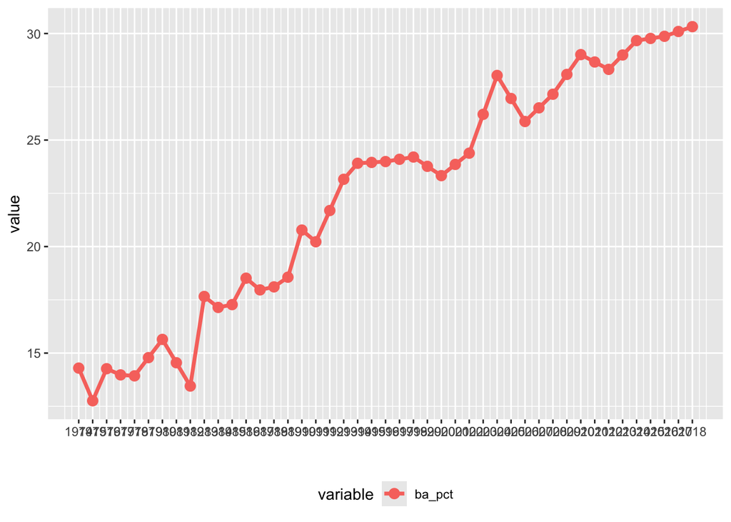

```r
ggMyTS(df = plot.dat, varlist = c("ba_pct"))
```

Life satisfaction

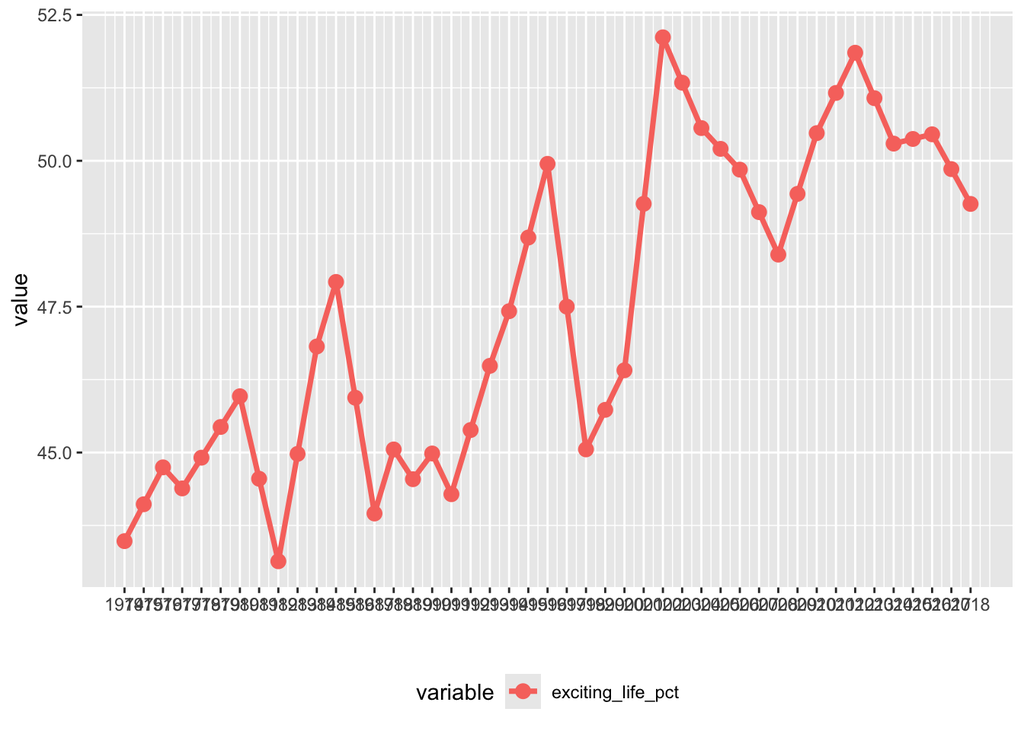

```r
ggMyTS(df = plot.dat, varlist = c("exciting_life_pct"))
```

Financial satisfaction

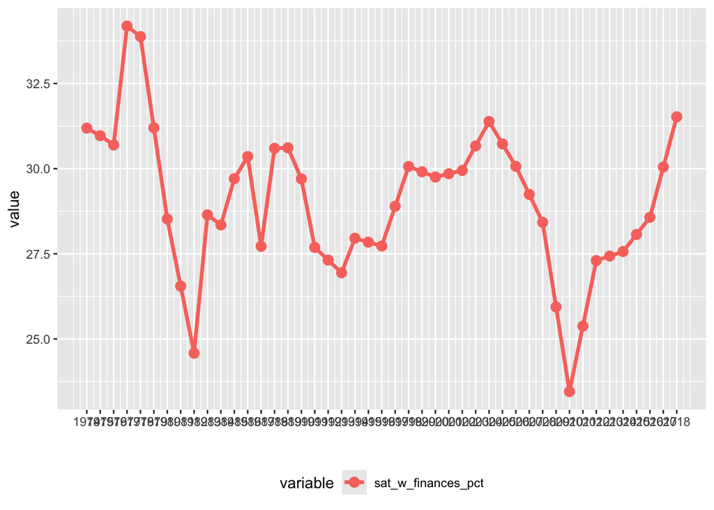

```r
ggMyTS(df = plot.dat, varlist = c("sat_w_finances_pct"))
```

Happiness

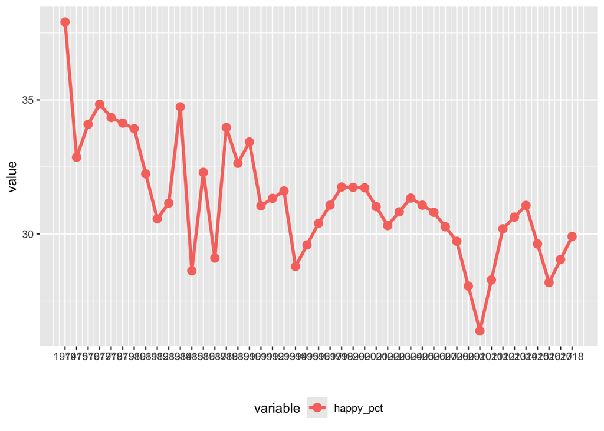

```r
(g_happy_pct <- ggMyTS(df = plot.dat, varlist = c("happy_pct")))
```

Self-Rated Health

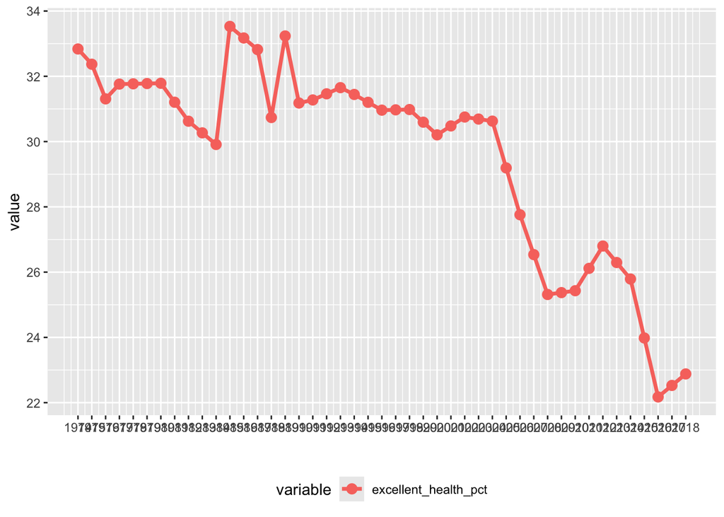

```r
ggMyTS(df = plot.dat, varlist = c("excellent_health_pct"))
```

Age Composition

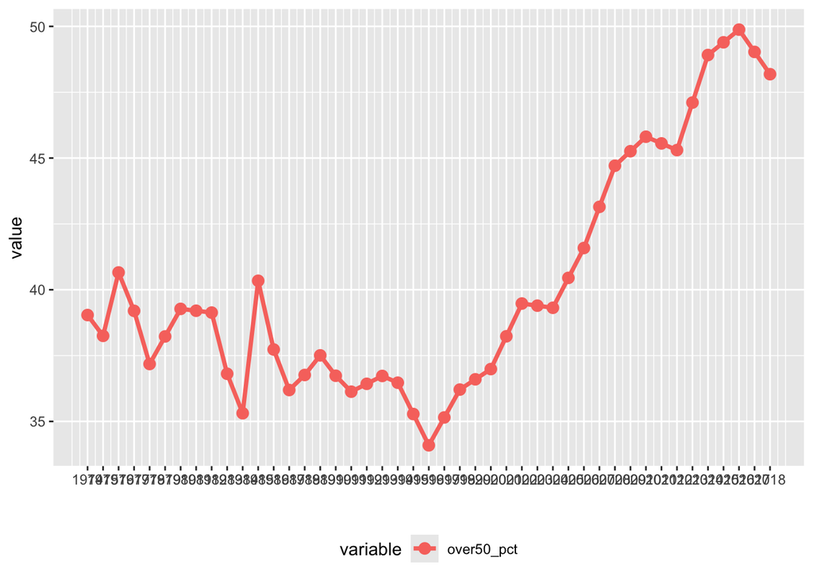

```r
ggMyTS(df = plot.dat, varlist = c("over50_pct"))
```

As expected, the percentage of the population with bachelor’s or higher increased through the years, as did percentage of people who rate their life as exciting. Financial satisfaction fluctuates. As stated before, health and happiness are decreasing. However, there are some cohort and age effects happening, and I will explore them further later.

## Q3: Simple time series regression

3. Run a simple time series regression, with one X and no trend. Interpret it.

```r
# simplest regression
lm.exciting_life <- lm(exciting_life_pct ~ ba_pct, data = by.year.ts)
summary(lm.exciting_life)
```

```
##
## Call:
## lm(formula = exciting_life_pct ~ ba_pct, data = by.year.ts)
##
## Residuals:
##     Min      1Q  Median      3Q     Max
## -3.1695 -0.7673 -0.0436  0.8981  3.8187
##
## Coefficients:
##             Estimate Std. Error t value Pr(>|t|)
## (Intercept) 38.36390    0.89022   43.09  < 2e-16 ***
## ba_pct       0.40736    0.03859   10.56 1.62e-13 ***
## ---
## Signif. codes:  0 '***' 0.001 '**' 0.01 '*' 0.05 '.' 0.1 ' ' 1
##
## Residual standard error: 1.436 on 43 degrees of freedom
## Multiple R-squared:  0.7216, Adjusted R-squared:  0.7151
## F-statistic: 111.5 on 1 and 43 DF,  p-value: 1.621e-13
```

The positive, highly significant coefficient, and high R squared of 0.72, suggests a strong association between percentage of people with higher degrees and people finding their life exciting over time. This indicates that years with a higher proportion of educated individuals correspond to higher life excitement.

```r
# test for heteroskedasticity
bptest(lm.exciting_life)
```

```
##
##  studentized Breusch-Pagan test
##
## data:  lm.exciting_life
## BP = 0.099067, df = 1, p-value = 0.753
```

The BP is not significant, so there is no heteroskedasticity.

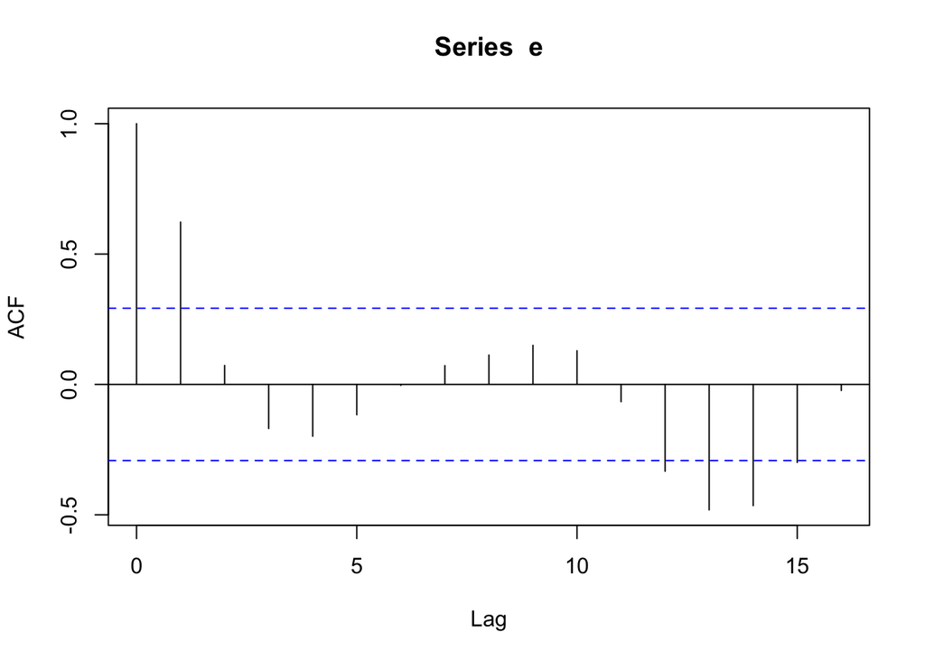

```r
# look for autocorrelation in errors
e <- lm.exciting_life$resid
acf(e)
```

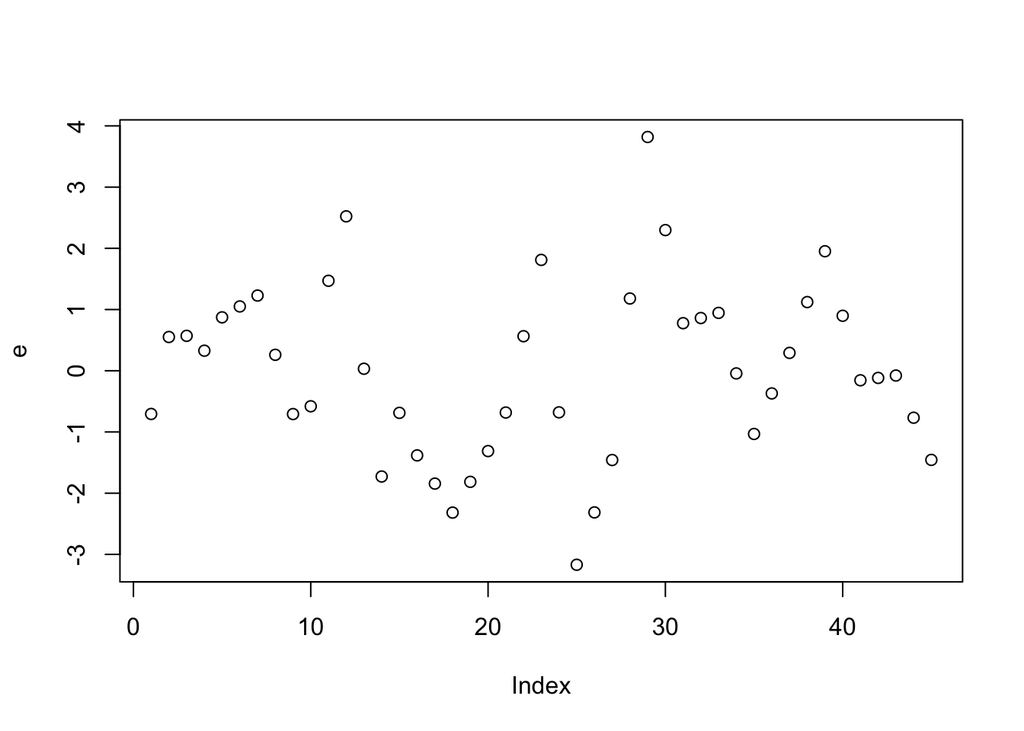

```r
plot(e) # plot residuals over time
```

```r
dwtest(lm.exciting_life) # Durbin-Watson test
```

```
##
##  Durbin-Watson test
##
## data:  lm.exciting_life
## DW = 0.72554, p-value = 2.17e-07
## alternative hypothesis: true autocorrelation is greater than 0
```

```r
bgtest(lm.exciting_life) # Breusch-Godfrey test
```

```
##
##  Breusch-Godfrey test for serial correlation of order up to 1
##
## data:  lm.exciting_life
## LM test = 17.913, df = 1, p-value = 2.312e-05
```

```r
durbinWatsonTest(lm.exciting_life, max.lag=3) # Durbin-Watson with more lags
```

```
##  lag Autocorrelation D-W Statistic p-value
##    1      0.62246085      0.725537   0.000
##    2      0.07278515      1.814817   0.560
##    3     -0.16910079      2.294853   0.262
##  Alternative hypothesis: rho[lag] != 0
```

Hence, the errors from the regression model are not independent over time. This violates OLS assumptions so we must explore more methods.

## Q4: TS regression with one X, trent, including autocorr diagnostics

4. Run a time series regression with one X and trend. Interpret it. Perform autocorrelation diagnostics. Explain what you found.

```r
# include year trend
lm.exciting_life2 <- update(lm.exciting_life, ~ . + year)
summary(lm.exciting_life2)
```

```
##
## Call:
## lm(formula = exciting_life_pct ~ ba_pct + year, data = by.year.ts)
##
## Residuals:
##     Min      1Q  Median      3Q     Max
## -3.0967 -0.9286 -0.0960  0.9107  3.7703
##
## Coefficients:
##              Estimate Std. Error t value Pr(>|t|)
## (Intercept) -27.42900  165.56367  -0.166    0.869
## ba_pct        0.32969    0.19932   1.654    0.106
## year          0.03383    0.08514   0.397    0.693
##
## Residual standard error: 1.45 on 42 degrees of freedom
## Multiple R-squared:  0.7227, Adjusted R-squared:  0.7094
## F-statistic: 54.72 on 2 and 42 DF,  p-value: 2.011e-12
```

After controlling for a linear time trend, the relationship between ba_pct and exciting_life_pct weakens in terms of statistical significance (p = .106 is not significant at alpha = 0.05 as standard, although, it is not that far from 0.05). This may indicate that the original relationship is partly spurious due to time trends. In addition, however, the time trend itself is not significant.

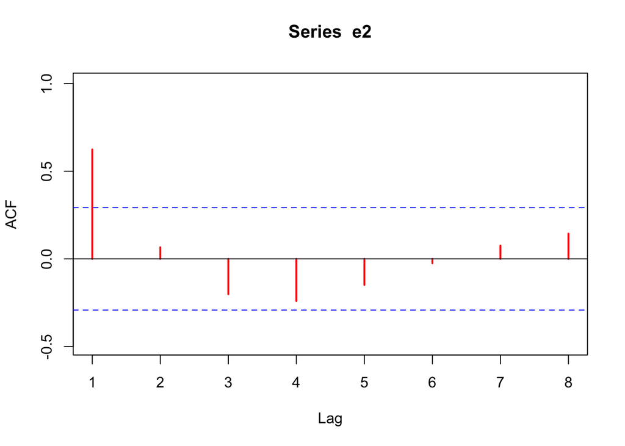

```r
# look for autocorrelation
e2 <- lm.exciting_life2$resid
acf(e2, xlim = c(1,8), col = "red", lwd = 2)
```

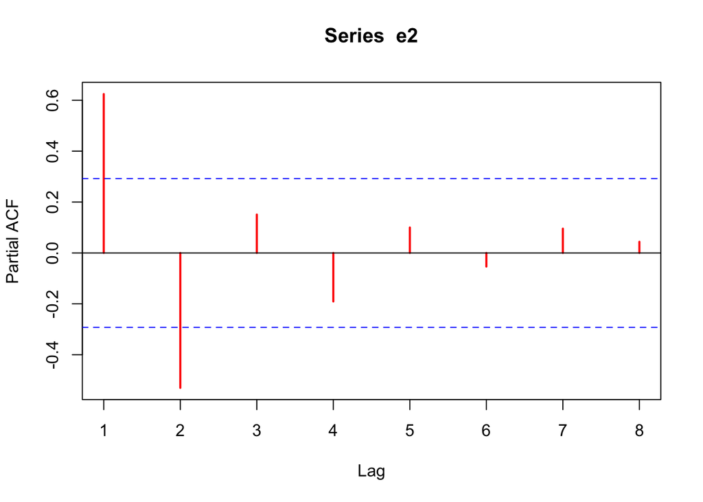

```r
pacf(e2, xlim = c(1,8), col = "red", lwd = 2)
```

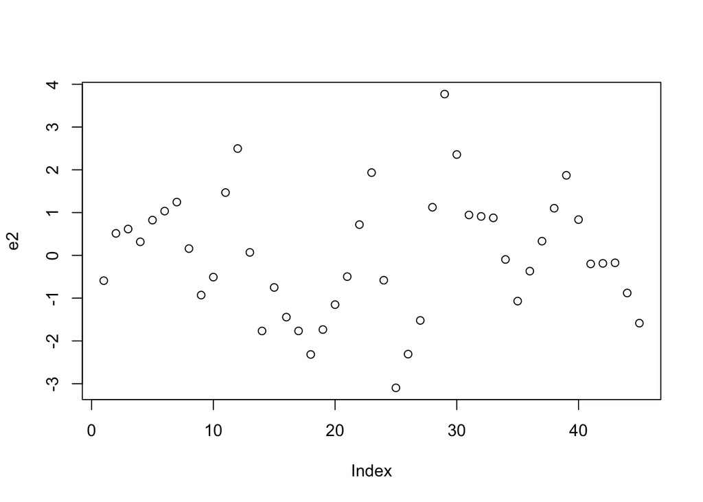

```r
plot(e2)
```

```r
coeftest(lm.exciting_life2, vcov = NeweyWest(lm.exciting_life2, lag = 1))
```

```
##
## t test of coefficients:
##
##               Estimate Std. Error t value Pr(>|t|)
## (Intercept) -27.429001 176.810074 -0.1551   0.8775
## ba_pct        0.329686   0.202725  1.6263   0.1114
## year          0.033834   0.090666  0.3732   0.7109
```

```r
dwtest(lm.exciting_life2)
```

```
##
##  Durbin-Watson test
##
## data:  lm.exciting_life2
## DW = 0.71906, p-value = 9.822e-08
## alternative hypothesis: true autocorrelation is greater than 0
```

```r
bgtest(lm.exciting_life2)
```

```
##
##  Breusch-Godfrey test for serial correlation of order up to 1
##
## data:  lm.exciting_life2
## LM test = 18.1, df = 1, p-value = 2.095e-05
```

```r
durbinWatsonTest(lm.exciting_life2, max.lag=3)
```

```
##  lag Autocorrelation D-W Statistic p-value
##    1      0.62427829     0.7190619   0.000
##    2      0.06622718     1.8234203   0.530
##    3     -0.20146932     2.3541809   0.176
##  Alternative hypothesis: rho[lag] != 0
```

The ACF plot shows strong positive autocorrelation at lag 1, which means the residuals are not independent over time (the residual at time 1 is correlated with the residual at t - 1). The PACF plot supports this. The residuals look random, but the other tests point to correlation.

The DW statistic for the new model is about 0.719, with a very small p-value. This is almost the same outcome as the original model without the trend and still indicates strong positive serial correlation in the residuals. The BG test small p value also indicates serial correlation in the residuals.

## Q5: TS regression with many Xs and trend, including VIF

5. Consider running a time series regression with many Xs and trend. Interpret that. Check VIF.

```r
# add some more predictors
lm.exciting_life3 <- update(lm.exciting_life2, ~ . + age + happy_pct + sat_w_finances_pct)
summary(lm.exciting_life3)
```

```
##
## Call:
## lm(formula = exciting_life_pct ~ ba_pct + year + age + happy_pct +
##     sat_w_finances_pct, data = by.year.ts)
##
## Residuals:
##     Min      1Q  Median      3Q     Max
## -3.2226 -0.8213  0.0290  0.8175  3.5080
##
## Coefficients:
##                     Estimate Std. Error t value Pr(>|t|)
## (Intercept)        -62.12276  222.35492  -0.279    0.781
## ba_pct               0.29485    0.22139   1.332    0.191
## year                 0.05586    0.11936   0.468    0.642
## age                 -0.16202    0.39865  -0.406    0.687
## happy_pct           -0.12781    0.17530  -0.729    0.470
## sat_w_finances_pct   0.10304    0.13392   0.769    0.446
##
## Residual standard error: 1.486 on 39 degrees of freedom
## Multiple R-squared:  0.7296, Adjusted R-squared:  0.695
## F-statistic: 21.05 on 5 and 39 DF,  p-value: 3.813e-10
```

```r
vif(lm.exciting_life3) # variance inflation factor
```

```
##             ba_pct               year                age          happy_pct
##          30.744641          48.975997           7.482813           2.938035
## sat_w_finances_pct
##           1.641323
```

```r
durbinWatsonTest(lm.exciting_life3, max.lag=2)
```

```
##  lag Autocorrelation D-W Statistic p-value
##    1      0.60992424      0.743718   0.000
##    2      0.06234572      1.826034   0.442
##  Alternative hypothesis: rho[lag] != 0
```

No predictors are significant in the multivariate regression with trend. The R-squared remains around 0.73, similar to prior models, suggesting that adding these variables does not substantially improve the model’s explanatory power. Similarly with the RSE, it is similar, so predictive accuracy has not improved.

ba_pct and year have very high VIFs (>> 10), suggesting high multicolinearity. The VIF for age is also high, indicating multicolinearity.

Let’s dry first differences as these models show they have issues.

## Q6: First differenced TS regression

6. Run a first differenced time series regression. Interpret that.

```r
firstD <- function(var, group, df){
  bad <- (missing(group) & !missing(df))
  if (bad) stop("if df is specified then group must also be specified")

  fD <- function(j){ c(NA, diff(j)) }

  var.is.alone <- missing(group) & missing(df)

  if (var.is.alone) {
    return(fD(var))
  }
  if (missing(df)){
    V <- var
    G <- group
  }
  else{
    V <- df[, deparse(substitute(var))]
    G <- df[, deparse(substitute(group))]
  }

  G <- list(G)
  D.var <- by(V, G, fD)
  unlist(D.var)
}

firstD <- function(var, group, df){
  bad <- (missing(group) & !missing(df))
  if (bad) stop("if df is specified then group must also be specified")

  fD <- function(j){ c(NA, diff(j)) }

  var.is.alone <- missing(group) & missing(df)

  if (var.is.alone) {
    return(fD(var))
  }
  if (missing(df)){
    V <- var
    G <- group
  }
  else{
    V <- df[, deparse(substitute(var))]
    G <- df[, deparse(substitute(group))]
  }

  G <- list(G)
  D.var <- by(V, G, fD)
  unlist(D.var)
}

## Use the first differences
by.yearFD <- summarise(data.frame(by.year.ts),
                       exciting_life_pct = firstD(exciting_life_pct), # using firstD functon from QMSS package
                       age = firstD(age),
                       ba_pct = firstD(ba_pct),
                       happy_pct = firstD(happy_pct),
                       income = firstD(income),
                       year = year)
lm.exciting_life4 <- update(lm.exciting_life2, data = by.yearFD)
summary(lm.exciting_life4)
```

```
##
## Call:
## lm(formula = exciting_life_pct ~ ba_pct + year, data = by.yearFD)
##
## Residuals:
##     Min      1Q  Median      3Q     Max
## -2.5091 -0.8515  0.1463  0.8360  2.7187
##
## Coefficients:
##             Estimate Std. Error t value Pr(>|t|)
## (Intercept) 13.89344   29.35720   0.473    0.639
## ba_pct       0.25440    0.18138   1.403    0.168
## year        -0.00694    0.01470  -0.472    0.639
##
## Residual standard error: 1.238 on 41 degrees of freedom
##   (1 observation deleted due to missingness)
## Multiple R-squared:  0.0509, Adjusted R-squared:  0.004605
## F-statistic: 1.099 on 2 and 41 DF,  p-value: 0.3427
```

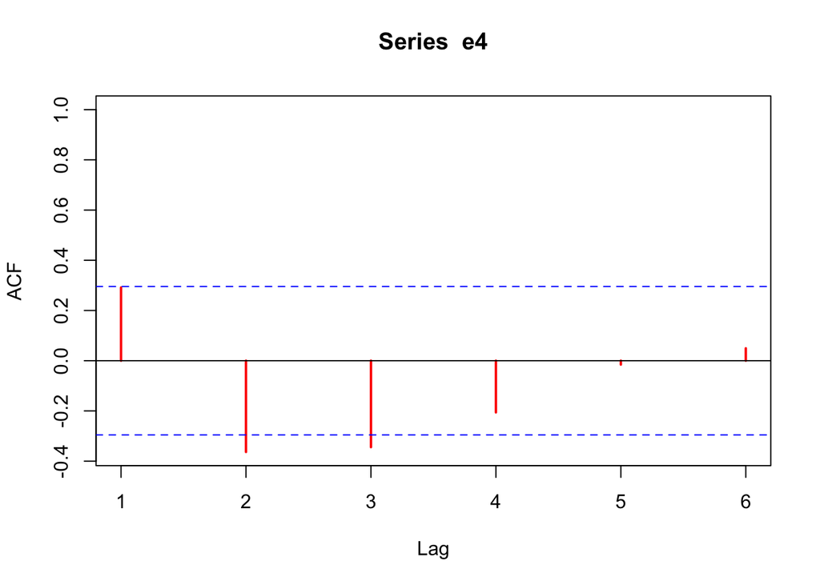

```r
e4 <- lm.exciting_life4$resid
acf(e4, xlim = c(1,6), col = "red", lwd = 2)
```

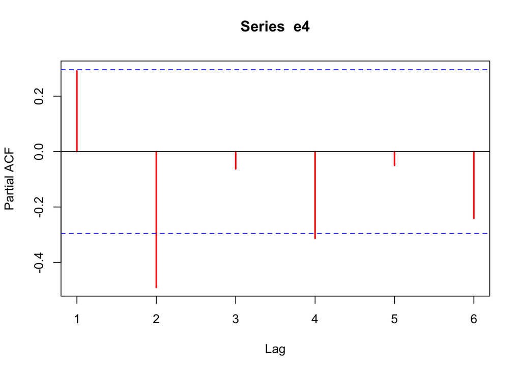

```r
pacf(e4, xlim = c(1,6), col = "red", lwd = 2)
```

```r
# library(forecast)
 auto.arima(e4, trace=TRUE)
```

```
##
##  ARIMA(2,0,2) with non-zero mean : Inf
##  ARIMA(0,0,0) with non-zero mean : 144.8753
##  ARIMA(1,0,0) with non-zero mean : 143.298
##  ARIMA(0,0,1) with non-zero mean : 135.6212
##  ARIMA(0,0,0) with zero mean     : 142.6778
##  ARIMA(1,0,1) with non-zero mean : 137.3828
##  ARIMA(0,0,2) with non-zero mean : 135.2193
##  ARIMA(1,0,2) with non-zero mean : Inf
##  ARIMA(0,0,3) with non-zero mean : Inf
##  ARIMA(1,0,3) with non-zero mean : Inf
##  ARIMA(0,0,2) with zero mean     : 132.7978
##  ARIMA(0,0,1) with zero mean     : 133.3141
##  ARIMA(1,0,2) with zero mean     : Inf
##  ARIMA(0,0,3) with zero mean     : 128.6516
##  ARIMA(1,0,3) with zero mean     : Inf
##  ARIMA(0,0,4) with zero mean     : 130.4606
##  ARIMA(1,0,4) with zero mean     : 133.0495
##
##  Best model: ARIMA(0,0,3) with zero mean
```

```
## Series: e4
## ARIMA(0,0,3) with zero mean
##
## Coefficients:
##          ma1      ma2      ma3
##       0.2957  -0.6477  -0.3556
## s.e.  0.1459   0.1506   0.1385
##
## sigma^2 = 0.9224:  log likelihood = -59.81
## AIC=127.63   AICc=128.65   BIC=134.76
```

The relationship between the percent of people with bachelors or higher and life excitement does not appear to be significant. After differencing, it appears that changes in exciting_life_pct are not strongly or significantly related to changes in ba_pct or to the passage of time (year), so the model does not provide evidence of a meaningful relationship in the differenced series. This either means there is no relationship or that we need to try another model.

## Q7: Check for unit roots

7. Check your variables for unit roots. Do some tests. Interpret them.

```r
## 7. Check your variables for unit roots.  Do some tests.  Interpret them.

adfTest(by.year.ts[,"exciting_life_pct"], lags = 0, type="ct")
```

```
##
## Title:
##  Augmented Dickey-Fuller Test
##
## Test Results:
##   PARAMETER:
##     Lag Order: 0
##   STATISTIC:
##     Dickey-Fuller: -2.7971
##   P VALUE:
##     0.2576
##
## Description:
##  Sat Dec 14 17:21:28 2024 by user:
```

```r
adfTest(by.year.ts[,"exciting_life_pct"], lags = 1, type="ct")
```

```
##
## Title:
##  Augmented Dickey-Fuller Test
##
## Test Results:
##   PARAMETER:
##     Lag Order: 1
##   STATISTIC:
##     Dickey-Fuller: -4.9471
##   P VALUE:
##     0.01
##
## Description:
##  Sat Dec 14 17:21:28 2024 by user:
```

```r
adfTest(by.year.ts[,"exciting_life_pct"], lags = 2, type="ct")
```

```
##
## Title:
##  Augmented Dickey-Fuller Test
##
## Test Results:
##   PARAMETER:
##     Lag Order: 2
##   STATISTIC:
##     Dickey-Fuller: -3.6634
##   P VALUE:
##     0.03883
##
## Description:
##  Sat Dec 14 17:21:28 2024 by user:
```

```r
adfTest(by.year.ts[,"exciting_life_pct"], lags = 4, type="ct")
```

```
##
## Title:
##  Augmented Dickey-Fuller Test
##
## Test Results:
##   PARAMETER:
##     Lag Order: 4
##   STATISTIC:
##     Dickey-Fuller: -2.8407
##   P VALUE:
##     0.2403
##
## Description:
##  Sat Dec 14 17:21:28 2024 by user:
```

```r
# Phillips-Perron test
PP.test(by.year.ts[,"exciting_life_pct"],lshort=TRUE)
```

```
##
##  Phillips-Perron Unit Root Test
##
## data:  by.year.ts[, "exciting_life_pct"]
## Dickey-Fuller = -3.0058, Truncation lag parameter = 3, p-value = 0.1748
```

```r
# BTW, Solution 1: use Newey & West autocorrelation consistent covariance matrix
# estimator

library(sandwich)
coeftest(lm.exciting_life3, vcov = NeweyWest(lm.exciting_life2, lag = 2))
```

```
##
## t test of coefficients:
##
##               Estimate Std. Error t value Pr(>|t|)
## (Intercept) -62.122762 155.856501 -0.3986   0.6924
## ba_pct        0.294855   0.177906  1.6574   0.1055
## year          0.055858   0.079874  0.6993   0.4885
```

## Q8: Automatic ARIMA on residuals

8. Perform an Automatic ARIMA on the residuals from one of your earlier models. Tell me what it says.

```r
library(forecast)
auto.arima(e2, trace=TRUE)
```

```
##
##  ARIMA(2,0,2) with non-zero mean : 127.8571
##  ARIMA(0,0,0) with non-zero mean : 162.338
##  ARIMA(1,0,0) with non-zero mean : 141.9318
##  ARIMA(0,0,1) with non-zero mean : 129.4635
##  ARIMA(0,0,0) with zero mean     : 160.1453
##  ARIMA(1,0,2) with non-zero mean : 126.3288
##  ARIMA(0,0,2) with non-zero mean : 123.7933
##  ARIMA(0,0,3) with non-zero mean : 126.3286
##  ARIMA(1,0,1) with non-zero mean : 125.6544
##  ARIMA(1,0,3) with non-zero mean : 129.0007
##  ARIMA(0,0,2) with zero mean     : 121.4035
##  ARIMA(0,0,1) with zero mean     : 127.1733
##  ARIMA(1,0,2) with zero mean     : 123.8156
##  ARIMA(0,0,3) with zero mean     : 123.8155
##  ARIMA(1,0,1) with zero mean     : 123.2696
##  ARIMA(1,0,3) with zero mean     : 126.3539
##
##  Best model: ARIMA(0,0,2) with zero mean
```

```
## Series: e2
## ARIMA(0,0,2) with zero mean
##
## Coefficients:
##          ma1     ma2
##       1.2262  0.4262
## s.e.  0.1401  0.1282
##
## sigma^2 = 0.756:  log likelihood = -57.41
## AIC=120.82   AICc=121.4   BIC=126.24
```

## Q9: ARIMA

9. Run an ARIMA that follows from Step 8. Interpret that, too.

```r
## 9. Run an ARIMA that follows from Step 7.  Interpret that, too.

xvars.fat <- by.year.ts[,c("ba_pct", "year")]

# ARIMA(0,0,0) = OLS
arima.001 <- arima(by.year.ts[,"exciting_life_pct"], order = c(0,0,1), xreg = xvars.fat)
summary(arima.001)
```

```
##
## Call:
## arima(x = by.year.ts[, "exciting_life_pct"], order = c(0, 0, 1), xreg = xvars.fat)
##
## Coefficients:
##          ma1  intercept  ba_pct     year
##       0.8504    38.9002  0.4095  -0.0003
## s.e.  0.0628   129.8960  0.1546   0.0667
##
## sigma^2 estimated as 0.8678:  log likelihood = -61.3,  aic = 132.61
##
## Training set error measures:
##                       ME     RMSE       MAE        MPE     MAPE      MASE
## Training set 0.005786688 0.931565 0.7324324 -0.0345866 1.546792 0.7122432
##                   ACF1
## Training set 0.3248455
```

```r
Box.test(resid(arima.001), lag = 20, type = c("Ljung-Box"), fitdf = 0)
```

```
##
##  Box-Ljung test
##
## data:  resid(arima.001)
## X-squared = 38.134, df = 20, p-value = 0.008529
```